# 1

```python
import warnings
warnings.filterwarnings('ignore')
import pandas as pd
```

```python
df = pd.read_csv('marketing_data.csv')
df[50:55]
```

|  | ID | Year_Birth | Education | Marital_Status | Income | Kidhome | Teenhome | Dt_Customer | Recency | MntWines | ... | NumStorePurchases | NumWebVisitsMonth | AcceptedCmp3 | AcceptedCmp4 | AcceptedCmp5 | AcceptedCmp1 | AcceptedCmp2 | Response | Complain | Country |
| --- | --- | --- | --- | --- | --- | --- | --- | --- | --- | --- | --- | --- | --- | --- | --- | --- | --- | --- | --- | --- | --- |
| 50 | 1241 | 1984 | 2n Cycle | Married | $14,796.00 | 1 | 0 | 9/17/12 | 1 | 13 | ... | 3 | 9 | 0 | 0 | 0 | 0 | 0 | 1 | 0 | GER |
| 51 | 1402 | 1954 | Master | Married | $66,991.00 | 0 | 0 | 9/11/12 | 1 | 496 | ... | 6 | 3 | 0 | 0 | 0 | 0 | 0 | 0 | 0 | GER |
| 52 | 7264 | 1978 | 2n Cycle | Single | $52,195.00 | 2 | 1 | 5/12/14 | 2 | 12 | ... | 2 | 8 | 0 | 0 | 0 | 0 | 0 | 0 | 0 | SA |
| 53 | 1619 | 1956 | Graduation | Married | $90,369.00 | 0 | 0 | 4/28/14 | 2 | 292 | ... | 6 | 1 | 0 | 0 | 0 | 0 | 0 | 1 | 0 | SP |
| 54 | 6398 | 1974 | Basic | Married | $18,393.00 | 1 | 0 | 3/29/14 | 2 | 7 | ... | 3 | 8 | 0 | 0 | 0 | 0 | 0 | 0 | 0 | SP |

5 rows × 28 columns

```python
df.shape, df.drop_duplicates().shape
```

```
((2240, 28), (2240, 28))
```

```python
df.info()
```

```
<class 'pandas.core.frame.DataFrame'>
RangeIndex: 2240 entries, 0 to 2239
Data columns (total 28 columns):
 #   Column               Non-Null Count  Dtype
---  ------               --------------  -----
 0   ID                   2240 non-null   int64
 1   Year_Birth           2240 non-null   int64
 2   Education            2240 non-null   object
 3   Marital_Status       2240 non-null   object
 4    Income              2216 non-null   object
 5   Kidhome              2240 non-null   int64
 6   Teenhome             2240 non-null   int64
 7   Dt_Customer          2240 non-null   object
 8   Recency              2240 non-null   int64
 9   MntWines             2240 non-null   int64
```

[output cut: 20 more lines]

- There are total 2240 rows and 28 columns in the dataframe
- Only Income has null value for 24 rows

# 2

## i, ii & iii

```python
df.dtypes
```

```
ID                      int64
Year_Birth              int64
Education              object
Marital_Status         object
 Income                object
Kidhome                 int64
Teenhome                int64
Dt_Customer            object
Recency                 int64
MntWines                int64
MntFruits               int64
MntMeatProducts         int64
MntFishProducts         int64
MntSweetProducts        int64
MntGoldProds            int64
NumDealsPurchases       int64
NumWebPurchases         int64
NumCatalogPurchases     int64
NumStorePurchases       int64
NumWebVisitsMonth       int64
AcceptedCmp3            int64
AcceptedCmp4            int64
AcceptedCmp5            int64
AcceptedCmp1            int64
AcceptedCmp2            int64
Response                int64
Complain                int64
Country                object
dtype: object
```

```python
df[df.columns[:15]].describe()
```

|  | ID | Year_Birth | Kidhome | Teenhome | Recency | MntWines | MntFruits | MntMeatProducts | MntFishProducts | MntSweetProducts | MntGoldProds |
| --- | --- | --- | --- | --- | --- | --- | --- | --- | --- | --- | --- |
| count | 2240.000000 | 2240.000000 | 2240.000000 | 2240.000000 | 2240.000000 | 2240.000000 | 2240.000000 | 2240.000000 | 2240.000000 | 2240.000000 | 2240.000000 |
| mean | 5592.159821 | 1968.805804 | 0.444196 | 0.506250 | 49.109375 | 303.935714 | 26.302232 | 166.950000 | 37.525446 | 27.062946 | 44.021875 |
| std | 3246.662198 | 11.984069 | 0.538398 | 0.544538 | 28.962453 | 336.597393 | 39.773434 | 225.715373 | 54.628979 | 41.280498 | 52.167439 |
| min | 0.000000 | 1893.000000 | 0.000000 | 0.000000 | 0.000000 | 0.000000 | 0.000000 | 0.000000 | 0.000000 | 0.000000 | 0.000000 |
| 25% | 2828.250000 | 1959.000000 | 0.000000 | 0.000000 | 24.000000 | 23.750000 | 1.000000 | 16.000000 | 3.000000 | 1.000000 | 9.000000 |
| 50% | 5458.500000 | 1970.000000 | 0.000000 | 0.000000 | 49.000000 | 173.500000 | 8.000000 | 67.000000 | 12.000000 | 8.000000 | 24.000000 |
| 75% | 8427.750000 | 1977.000000 | 1.000000 | 1.000000 | 74.000000 | 504.250000 | 33.000000 | 232.000000 | 50.000000 | 33.000000 | 56.000000 |
| max | 11191.000000 | 1996.000000 | 2.000000 | 2.000000 | 99.000000 | 1493.000000 | 199.000000 | 1725.000000 | 259.000000 | 263.000000 | 362.000000 |

```python
df[df.columns[15:]].describe()
```

|  | NumDealsPurchases | NumWebPurchases | NumCatalogPurchases | NumStorePurchases | NumWebVisitsMonth | AcceptedCmp3 | AcceptedCmp4 | AcceptedCmp5 | AcceptedCmp1 | AcceptedCmp2 | Response | Complain |
| --- | --- | --- | --- | --- | --- | --- | --- | --- | --- | --- | --- | --- |
| count | 2240.000000 | 2240.000000 | 2240.000000 | 2240.000000 | 2240.000000 | 2240.000000 | 2240.000000 | 2240.000000 | 2240.000000 | 2240.000000 | 2240.000000 | 2240.000000 |
| mean | 2.325000 | 4.084821 | 2.662054 | 5.790179 | 5.316518 | 0.072768 | 0.074554 | 0.072768 | 0.064286 | 0.013393 | 0.149107 | 0.009375 |
| std | 1.932238 | 2.778714 | 2.923101 | 3.250958 | 2.426645 | 0.259813 | 0.262728 | 0.259813 | 0.245316 | 0.114976 | 0.356274 | 0.096391 |
| min | 0.000000 | 0.000000 | 0.000000 | 0.000000 | 0.000000 | 0.000000 | 0.000000 | 0.000000 | 0.000000 | 0.000000 | 0.000000 | 0.000000 |
| 25% | 1.000000 | 2.000000 | 0.000000 | 3.000000 | 3.000000 | 0.000000 | 0.000000 | 0.000000 | 0.000000 | 0.000000 | 0.000000 | 0.000000 |
| 50% | 2.000000 | 4.000000 | 2.000000 | 5.000000 | 6.000000 | 0.000000 | 0.000000 | 0.000000 | 0.000000 | 0.000000 | 0.000000 | 0.000000 |
| 75% | 3.000000 | 6.000000 | 4.000000 | 8.000000 | 7.000000 | 0.000000 | 0.000000 | 0.000000 | 0.000000 | 0.000000 | 0.000000 | 0.000000 |
| max | 15.000000 | 27.000000 | 28.000000 | 13.000000 | 20.000000 | 1.000000 | 1.000000 | 1.000000 | 1.000000 | 1.000000 | 1.000000 | 1.000000 |

- There are 4 categorical columns

# 3

```python
df.isnull().sum()
```

```
ID                      0
Year_Birth              0
Education               0
Marital_Status          0
 Income                24
Kidhome                 0
Teenhome                0
Dt_Customer             0
Recency                 0
MntWines                0
MntFruits               0
MntMeatProducts         0
MntFishProducts         0
MntSweetProducts        0
MntGoldProds            0
NumDealsPurchases       0
NumWebPurchases         0
NumCatalogPurchases     0
NumStorePurchases       0
NumWebVisitsMonth       0
AcceptedCmp3            0
AcceptedCmp4            0
AcceptedCmp5            0
AcceptedCmp1            0
AcceptedCmp2            0
Response                0
Complain                0
Country                 0
dtype: int64
```

```python
df.rename(columns={' Income ':'Income'}, inplace=True)
```

```python
df.dropna(subset=['Income'], inplace=True)
df.reset_index(drop=True, inplace=True)
```

```python
df.isnull().sum()
```

```
ID                     0
Year_Birth             0
Education              0
Marital_Status         0
Income                 0
Kidhome                0
Teenhome               0
Dt_Customer            0
Recency                0
MntWines               0
MntFruits              0
MntMeatProducts        0
MntFishProducts        0
MntSweetProducts       0
MntGoldProds           0
NumDealsPurchases      0
NumWebPurchases        0
NumCatalogPurchases    0
NumStorePurchases      0
NumWebVisitsMonth      0
AcceptedCmp3           0
AcceptedCmp4           0
AcceptedCmp5           0
AcceptedCmp1           0
AcceptedCmp2           0
Response               0
Complain               0
Country                0
dtype: int64
```

# 4

```python
df.dtypes
```

```
ID                      int64
Year_Birth              int64
Education              object
Marital_Status         object
Income                 object
Kidhome                 int64
Teenhome                int64
Dt_Customer            object
Recency                 int64
MntWines                int64
MntFruits               int64
MntMeatProducts         int64
MntFishProducts         int64
MntSweetProducts        int64
MntGoldProds            int64
NumDealsPurchases       int64
NumWebPurchases         int64
NumCatalogPurchases     int64
NumStorePurchases       int64
NumWebVisitsMonth       int64
AcceptedCmp3            int64
AcceptedCmp4            int64
AcceptedCmp5            int64
AcceptedCmp1            int64
AcceptedCmp2            int64
Response                int64
Complain                int64
Country                object
dtype: object
```

```python
df['Income']
```

```
0       $84,835.00
1       $57,091.00
2       $67,267.00
3       $32,474.00
4       $21,474.00
           ...
2211    $66,476.00
2212    $31,056.00
2213    $46,310.00
2214    $65,819.00
2215    $94,871.00
Name: Income, Length: 2216, dtype: object
```

```python
df['Income'] = df['Income'].apply(lambda x: x.replace('$', '').replace(',', ''))
df['Income'] = df['Income'].astype(float)
```

```python
df['Income']
```

```
0       84835.0
1       57091.0
2       67267.0
3       32474.0
4       21474.0
         ...
2211    66476.0
2212    31056.0
2213    46310.0
2214    65819.0
2215    94871.0
Name: Income, Length: 2216, dtype: float64
```

```python
df.dtypes
```

```
ID                       int64
Year_Birth               int64
Education               object
Marital_Status          object
Income                 float64
Kidhome                  int64
Teenhome                 int64
Dt_Customer             object
Recency                  int64
MntWines                 int64
MntFruits                int64
MntMeatProducts          int64
MntFishProducts          int64
MntSweetProducts         int64
MntGoldProds             int64
NumDealsPurchases        int64
NumWebPurchases          int64
NumCatalogPurchases      int64
NumStorePurchases        int64
NumWebVisitsMonth        int64
AcceptedCmp3             int64
AcceptedCmp4             int64
AcceptedCmp5             int64
AcceptedCmp1             int64
AcceptedCmp2             int64
Response                 int64
Complain                 int64
Country                 object
dtype: object
```

# 5

```python
df.head(3)
```

|  | ID | Year_Birth | Education | Marital_Status | Income | Kidhome | Teenhome | Dt_Customer | Recency | MntWines | ... | NumStorePurchases | NumWebVisitsMonth | AcceptedCmp3 | AcceptedCmp4 | AcceptedCmp5 | AcceptedCmp1 | AcceptedCmp2 | Response | Complain | Country |
| --- | --- | --- | --- | --- | --- | --- | --- | --- | --- | --- | --- | --- | --- | --- | --- | --- | --- | --- | --- | --- | --- |
| 0 | 1826 | 1970 | Graduation | Divorced | 84835.0 | 0 | 0 | 6/16/14 | 0 | 189 | ... | 6 | 1 | 0 | 0 | 0 | 0 | 0 | 1 | 0 | SP |
| 1 | 1 | 1961 | Graduation | Single | 57091.0 | 0 | 0 | 6/15/14 | 0 | 464 | ... | 7 | 5 | 0 | 0 | 0 | 0 | 1 | 1 | 0 | CA |
| 2 | 10476 | 1958 | Graduation | Married | 67267.0 | 0 | 1 | 5/13/14 | 0 | 134 | ... | 5 | 2 | 0 | 0 | 0 | 0 | 0 | 0 | 0 | US |

3 rows × 28 columns

```python
df.columns
```

```
Index(['ID', 'Year_Birth', 'Education', 'Marital_Status', 'Income', 'Kidhome',
       'Teenhome', 'Dt_Customer', 'Recency', 'MntWines', 'MntFruits',
       'MntMeatProducts', 'MntFishProducts', 'MntSweetProducts',
       'MntGoldProds', 'NumDealsPurchases', 'NumWebPurchases',
       'NumCatalogPurchases', 'NumStorePurchases', 'NumWebVisitsMonth',
       'AcceptedCmp3', 'AcceptedCmp4', 'AcceptedCmp5', 'AcceptedCmp1',
       'AcceptedCmp2', 'Response', 'Complain', 'Country'],
      dtype='object')
```

```python
df['age'] = 2022 - df['Year_Birth']
```

```python
import matplotlib.pyplot as plt
%matplotlib inline
import seaborn as sns
```

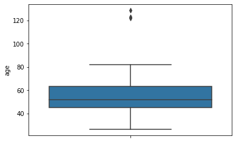

```python
sns.boxplot(y=df['age'])
```

```python
df['age'].describe()
```

```
count    2216.000000
mean       53.179603
std        11.985554
min        26.000000
25%        45.000000
50%        52.000000
75%        63.000000
max       129.000000
Name: age, dtype: float64
```

- There are a few anomalies in the columns 'age'

# 6

## a

```python
df.head(1)
```

|  | ID | Year_Birth | Education | Marital_Status | Income | Kidhome | Teenhome | Dt_Customer | Recency | MntWines | ... | NumWebVisitsMonth | AcceptedCmp3 | AcceptedCmp4 | AcceptedCmp5 | AcceptedCmp1 | AcceptedCmp2 | Response | Complain | Country | age |
| --- | --- | --- | --- | --- | --- | --- | --- | --- | --- | --- | --- | --- | --- | --- | --- | --- | --- | --- | --- | --- | --- |
| 0 | 1826 | 1970 | Graduation | Divorced | 84835.0 | 0 | 0 | 6/16/14 | 0 | 189 | ... | 1 | 0 | 0 | 0 | 0 | 0 | 1 | 0 | SP | 52 |

1 rows × 29 columns

```python
df.nunique()
```

```
ID                     2216
Year_Birth               59
Education                 5
Marital_Status            8
Income                 1974
Kidhome                   3
Teenhome                  3
Dt_Customer             662
Recency                 100
MntWines                776
MntFruits               158
MntMeatProducts         554
MntFishProducts         182
MntSweetProducts        176
MntGoldProds            212
NumDealsPurchases        15
NumWebPurchases          15
NumCatalogPurchases      14
NumStorePurchases        14
NumWebVisitsMonth        16
AcceptedCmp3              2
AcceptedCmp4              2
AcceptedCmp5              2
AcceptedCmp1              2
AcceptedCmp2              2
Response                  2
Complain                  2
Country                   8
age                      59
dtype: int64
```

```python
df['total_amount'] = df['MntWines'] + df['MntFruits'] + df['MntMeatProducts'] + df['MntFishProducts'] +\
df['MntSweetProducts'] + df['MntGoldProds']
```

```python
df.head(1)
```

|  | ID | Year_Birth | Education | Marital_Status | Income | Kidhome | Teenhome | Dt_Customer | Recency | MntWines | ... | AcceptedCmp3 | AcceptedCmp4 | AcceptedCmp5 | AcceptedCmp1 | AcceptedCmp2 | Response | Complain | Country | age | total_amount |
| --- | --- | --- | --- | --- | --- | --- | --- | --- | --- | --- | --- | --- | --- | --- | --- | --- | --- | --- | --- | --- | --- |
| 0 | 1826 | 1970 | Graduation | Divorced | 84835.0 | 0 | 0 | 6/16/14 | 0 | 189 | ... | 0 | 0 | 0 | 0 | 0 | 1 | 0 | SP | 52 | 1190 |

1 rows × 30 columns

## b

- % of amount spent on wine and other products at each customer level

```python
df['%amount_spent_on_wine_each_customer'] = (df['MntWines']/df['total_amount'])*100
df['%amount_spent_on_wine_each_customer'] = df['%amount_spent_on_wine_each_customer'].round(2)
df['%amount_spent_on_other_prods_each_customer'] = 100 - df['%amount_spent_on_wine_each_customer']
```

```python
df.head()
```

|  | ID | Year_Birth | Education | Marital_Status | Income | Kidhome | Teenhome | Dt_Customer | Recency | MntWines | ... | AcceptedCmp5 | AcceptedCmp1 | AcceptedCmp2 | Response | Complain | Country | age | total_amount | %amount_spent_on_wine_each_customer | %amount_spent_on_other_prods_each_customer |
| --- | --- | --- | --- | --- | --- | --- | --- | --- | --- | --- | --- | --- | --- | --- | --- | --- | --- | --- | --- | --- | --- |
| 0 | 1826 | 1970 | Graduation | Divorced | 84835.0 | 0 | 0 | 6/16/14 | 0 | 189 | ... | 0 | 0 | 0 | 1 | 0 | SP | 52 | 1190 | 15.88 | 84.12 |
| 1 | 1 | 1961 | Graduation | Single | 57091.0 | 0 | 0 | 6/15/14 | 0 | 464 | ... | 0 | 0 | 1 | 1 | 0 | CA | 61 | 577 | 80.42 | 19.58 |
| 2 | 10476 | 1958 | Graduation | Married | 67267.0 | 0 | 1 | 5/13/14 | 0 | 134 | ... | 0 | 0 | 0 | 0 | 0 | US | 64 | 251 | 53.39 | 46.61 |
| 3 | 1386 | 1967 | Graduation | Together | 32474.0 | 1 | 1 | 5/11/14 | 0 | 10 | ... | 0 | 0 | 0 | 0 | 0 | AUS | 55 | 11 | 90.91 | 9.09 |
| 4 | 5371 | 1989 | Graduation | Single | 21474.0 | 1 | 0 | 4/8/14 | 0 | 6 | ... | 0 | 0 | 0 | 1 | 0 | SP | 33 | 91 | 6.59 | 93.41 |

5 rows × 32 columns

```python
df['%amount_spent_on_wine_each_customer'].describe()
```

```
count    2216.000000
mean       45.870009
std        22.855613
min         0.000000
25%        28.950000
50%        45.780000
75%        64.105000
max        96.330000
Name: %amount_spent_on_wine_each_customer, dtype: float64
```

```python
df['%amount_spent_on_other_prods_each_customer'].describe()
```

```
count    2216.000000
mean       54.129991
std        22.855613
min         3.670000
25%        35.895000
50%        54.220000
75%        71.050000
max       100.000000
Name: %amount_spent_on_other_prods_each_customer, dtype: float64
```

- % of amount spent on wine and other products for all customers grouped together

```python
# % amount spent on wine

round((df['MntWines'].sum()/df['total_amount'].sum()*100), 2)
```

```
50.26
```

```python
# % amount spent on other products

100-round((df['MntWines'].sum()/df['total_amount'].sum()*100), 2)
```

```
49.74
```

# 7

## a

```python
df.head(1)
```

|  | ID | Year_Birth | Education | Marital_Status | Income | Kidhome | Teenhome | Dt_Customer | Recency | MntWines | ... | AcceptedCmp5 | AcceptedCmp1 | AcceptedCmp2 | Response | Complain | Country | age | total_amount | %amount_spent_on_wine_each_customer | %amount_spent_on_other_prods_each_customer |
| --- | --- | --- | --- | --- | --- | --- | --- | --- | --- | --- | --- | --- | --- | --- | --- | --- | --- | --- | --- | --- | --- |
| 0 | 1826 | 1970 | Graduation | Divorced | 84835.0 | 0 | 0 | 6/16/14 | 0 | 189 | ... | 0 | 0 | 0 | 1 | 0 | SP | 52 | 1190 | 15.88 | 84.12 |

1 rows × 32 columns

```python
df.nunique()
```

```
ID                                            2216
Year_Birth                                      59
Education                                        5
Marital_Status                                   8
Income                                        1974
Kidhome                                          3
Teenhome                                         3
Dt_Customer                                    662
Recency                                        100
MntWines                                       776
MntFruits                                      158
MntMeatProducts                                554
MntFishProducts                                182
MntSweetProducts                               176
MntGoldProds                                   212
NumDealsPurchases                               15
NumWebPurchases                                 15
NumCatalogPurchases                             14
NumStorePurchases                               14
NumWebVisitsMonth                               16
AcceptedCmp3                                     2
AcceptedCmp4                                     2
AcceptedCmp5                                     2
AcceptedCmp1                                     2
AcceptedCmp2                                     2
Response                                         2
Complain                                         2
Country                                          8
age                                             59
total_amount                                  1047
%amount_spent_on_wine_each_customer           1601
%amount_spent_on_other_prods_each_customer    1601
dtype: int64
```

```python
df['total_purchase'] = df['NumDealsPurchases'] + df['NumWebPurchases'] + df['NumCatalogPurchases'] +\
df['NumStorePurchases'] + df['NumStorePurchases']
```

```python
df.head(1)
```

|  | ID | Year_Birth | Education | Marital_Status | Income | Kidhome | Teenhome | Dt_Customer | Recency | MntWines | ... | AcceptedCmp1 | AcceptedCmp2 | Response | Complain | Country | age | total_amount | %amount_spent_on_wine_each_customer | %amount_spent_on_other_prods_each_customer | total_purchase |
| --- | --- | --- | --- | --- | --- | --- | --- | --- | --- | --- | --- | --- | --- | --- | --- | --- | --- | --- | --- | --- | --- |
| 0 | 1826 | 1970 | Graduation | Divorced | 84835.0 | 0 | 0 | 6/16/14 | 0 | 189 | ... | 0 | 0 | 1 | 0 | SP | 52 | 1190 | 15.88 | 84.12 | 21 |

1 rows × 33 columns

## b

- % of store purchases at each customer level

```python
df['%store_purchases_each_customer'] = (df['NumStorePurchases']/df['total_purchase'])*100
df['%store_purchases_each_customer'] = df['%store_purchases_each_customer'].round(2)
df['%other_channel_purchase_each_customer'] = 100 - df['%store_purchases_each_customer']
```

```python
df.head()
```

|  | ID | Year_Birth | Education | Marital_Status | Income | Kidhome | Teenhome | Dt_Customer | Recency | MntWines | ... | Response | Complain | Country | age | total_amount | %amount_spent_on_wine_each_customer | %amount_spent_on_other_prods_each_customer | total_purchase | %store_purchases_each_customer | %other_channel_purchase_each_customer |
| --- | --- | --- | --- | --- | --- | --- | --- | --- | --- | --- | --- | --- | --- | --- | --- | --- | --- | --- | --- | --- | --- |
| 0 | 1826 | 1970 | Graduation | Divorced | 84835.0 | 0 | 0 | 6/16/14 | 0 | 189 | ... | 1 | 0 | SP | 52 | 1190 | 15.88 | 84.12 | 21 | 28.57 | 71.43 |
| 1 | 1 | 1961 | Graduation | Single | 57091.0 | 0 | 0 | 6/15/14 | 0 | 464 | ... | 1 | 0 | CA | 61 | 577 | 80.42 | 19.58 | 25 | 28.00 | 72.00 |
| 2 | 10476 | 1958 | Graduation | Married | 67267.0 | 0 | 1 | 5/13/14 | 0 | 134 | ... | 0 | 0 | US | 64 | 251 | 53.39 | 46.61 | 16 | 31.25 | 68.75 |
| 3 | 1386 | 1967 | Graduation | Together | 32474.0 | 1 | 1 | 5/11/14 | 0 | 10 | ... | 0 | 0 | AUS | 55 | 11 | 90.91 | 9.09 | 6 | 33.33 | 66.67 |
| 4 | 5371 | 1989 | Graduation | Single | 21474.0 | 1 | 0 | 4/8/14 | 0 | 6 | ... | 1 | 0 | SP | 33 | 91 | 6.59 | 93.41 | 10 | 20.00 | 80.00 |

5 rows × 35 columns

```python
df['%store_purchases_each_customer'].describe()
```

```
count    2212.000000
mean       28.552884
std         6.129409
min         0.000000
25%        25.000000
50%        29.170000
75%        33.330000
max        50.000000
Name: %store_purchases_each_customer, dtype: float64
```

```python
df['%other_channel_purchase_each_customer'].describe()
```

```
count    2212.000000
mean       71.447116
std         6.129409
min        50.000000
25%        66.670000
50%        70.830000
75%        75.000000
max       100.000000
Name: %other_channel_purchase_each_customer, dtype: float64
```

- % of store purchases and other purchases for all customers grouped together

```python
# % store purchases

round((df['NumStorePurchases'].sum()/df['total_purchase'].sum()*100), 2)
```

```
28.05
```

```python
# % purchases through other channels

100-round((df['NumStorePurchases'].sum()/df['total_purchase'].sum()*100), 2)
```

```
71.95
```

# 8

```python
df.columns
```

```
Index(['ID', 'Year_Birth', 'Education', 'Marital_Status', 'Income', 'Kidhome',
       'Teenhome', 'Dt_Customer', 'Recency', 'MntWines', 'MntFruits',
       'MntMeatProducts', 'MntFishProducts', 'MntSweetProducts',
       'MntGoldProds', 'NumDealsPurchases', 'NumWebPurchases',
       'NumCatalogPurchases', 'NumStorePurchases', 'NumWebVisitsMonth',
       'AcceptedCmp3', 'AcceptedCmp4', 'AcceptedCmp5', 'AcceptedCmp1',
       'AcceptedCmp2', 'Response', 'Complain', 'Country', 'age',
       'total_amount', '%amount_spent_on_wine_each_customer',
       '%amount_spent_on_other_prods_each_customer', 'total_purchase',
       '%store_purchases_each_customer',
       '%other_channel_purchase_each_customer'],
      dtype='object')
```

```python
df[['AcceptedCmp3', 'AcceptedCmp4', 'AcceptedCmp5', 'AcceptedCmp1',
       'AcceptedCmp2']].head()
```

|  | AcceptedCmp3 | AcceptedCmp4 | AcceptedCmp5 | AcceptedCmp1 | AcceptedCmp2 |
| --- | --- | --- | --- | --- | --- |
| 0 | 0 | 0 | 0 | 0 | 0 |
| 1 | 0 | 0 | 0 | 0 | 1 |
| 2 | 0 | 0 | 0 | 0 | 0 |
| 3 | 0 | 0 | 0 | 0 | 0 |
| 4 | 1 | 0 | 0 | 0 | 0 |

[output not shown]

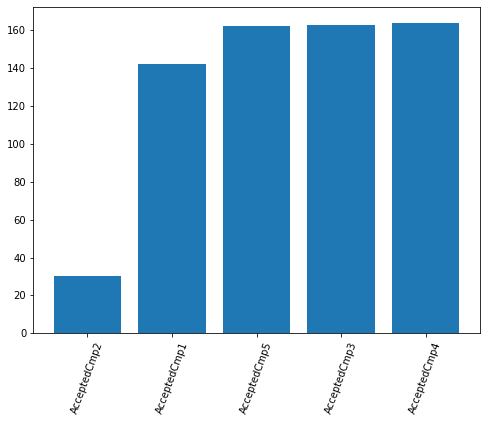

```python
plt.figure(figsize=(8,6))
plt.bar(df[['AcceptedCmp3', 'AcceptedCmp4', 'AcceptedCmp5', 'AcceptedCmp1',
       'AcceptedCmp2']].sum().reset_index().sort_values(by=[0])['index'], df[['AcceptedCmp3', 'AcceptedCmp4', 'AcceptedCmp5', 'AcceptedCmp1',
       'AcceptedCmp2']].sum().reset_index().sort_values(by=[0])[0])
plt.xticks(rotation=70)
```

```python
df[['AcceptedCmp3', 'AcceptedCmp4', 'AcceptedCmp5', 'AcceptedCmp1',
       'AcceptedCmp2']].sum().sort_values()
```

```
AcceptedCmp2     30
AcceptedCmp1    142
AcceptedCmp5    162
AcceptedCmp3    163
AcceptedCmp4    164
dtype: int64
```

# 9

```python
df.columns
```

```
Index(['ID', 'Year_Birth', 'Education', 'Marital_Status', 'Income', 'Kidhome',
       'Teenhome', 'Dt_Customer', 'Recency', 'MntWines', 'MntFruits',
       'MntMeatProducts', 'MntFishProducts', 'MntSweetProducts',
       'MntGoldProds', 'NumDealsPurchases', 'NumWebPurchases',
       'NumCatalogPurchases', 'NumStorePurchases', 'NumWebVisitsMonth',
       'AcceptedCmp3', 'AcceptedCmp4', 'AcceptedCmp5', 'AcceptedCmp1',
       'AcceptedCmp2', 'Response', 'Complain', 'Country', 'age',
       'total_amount', '%amount_spent_on_wine_each_customer',
       '%amount_spent_on_other_prods_each_customer', 'total_purchase',
       '%store_purchases_each_customer',
       '%other_channel_purchase_each_customer'],
      dtype='object')
```

```python
df[['MntWines', 'MntFruits', 'MntMeatProducts', 'MntFishProducts', 'MntSweetProducts','MntGoldProds']].head()
```

|  | MntWines | MntFruits | MntMeatProducts | MntFishProducts | MntSweetProducts | MntGoldProds |
| --- | --- | --- | --- | --- | --- | --- |
| 0 | 189 | 104 | 379 | 111 | 189 | 218 |
| 1 | 464 | 5 | 64 | 7 | 0 | 37 |
| 2 | 134 | 11 | 59 | 15 | 2 | 30 |
| 3 | 10 | 0 | 1 | 0 | 0 | 0 |
| 4 | 6 | 16 | 24 | 11 | 0 | 34 |

[output not shown]

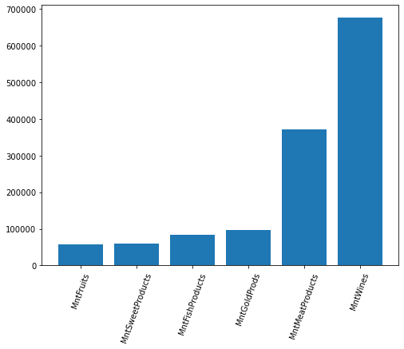

```python
plt.figure(figsize=(8,6))
plt.bar(df[['MntWines', 'MntFruits', 'MntMeatProducts', 'MntFishProducts', 'MntSweetProducts','MntGoldProds']].sum().reset_index().sort_values(by=[0])['index'], df[['MntWines', 'MntFruits', 'MntMeatProducts', 'MntFishProducts', 'MntSweetProducts','MntGoldProds']].sum().reset_index().sort_values(by=[0])[0])
plt.xticks(rotation=70)
```

```python
df[['MntWines', 'MntFruits', 'MntMeatProducts', 'MntFishProducts', 'MntSweetProducts','MntGoldProds']].sum().sort_values()
```

```
MntFruits            58405
MntSweetProducts     59896
MntFishProducts      83405
MntGoldProds         97427
MntMeatProducts     370063
MntWines            676083
dtype: int64
```

# 10

```python
df_accp = df[df['AcceptedCmp5'] == 1]
df_accp.reset_index(drop=True, inplace=True)
```

```python
df_accp = df_accp[['age', 'AcceptedCmp5']]
df_accp.head(2)
```

|  | age | AcceptedCmp5 |
| --- | --- | --- |
| 0 | 35 | 1 |
| 1 | 61 | 1 |

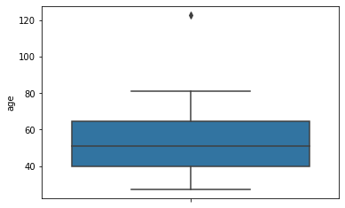

```python
sns.boxplot(y=df_accp['age']) # age distribution of people who accepted the last campaign
```

# 11

```python
df.columns
```

```
Index(['ID', 'Year_Birth', 'Education', 'Marital_Status', 'Income', 'Kidhome',
       'Teenhome', 'Dt_Customer', 'Recency', 'MntWines', 'MntFruits',
       'MntMeatProducts', 'MntFishProducts', 'MntSweetProducts',
       'MntGoldProds', 'NumDealsPurchases', 'NumWebPurchases',
       'NumCatalogPurchases', 'NumStorePurchases', 'NumWebVisitsMonth',
       'AcceptedCmp3', 'AcceptedCmp4', 'AcceptedCmp5', 'AcceptedCmp1',
       'AcceptedCmp2', 'Response', 'Complain', 'Country', 'age',
       'total_amount', '%amount_spent_on_wine_each_customer',
       '%amount_spent_on_other_prods_each_customer', 'total_purchase',
       '%store_purchases_each_customer',
       '%other_channel_purchase_each_customer'],
      dtype='object')
```

```python
df_country = df[['Country', 'AcceptedCmp5']]
df_country = df_country[df_country['AcceptedCmp5'] == 1]
df_country.reset_index(drop=True, inplace=True)
```

```python
df_country.head(1)
```

|  | Country | AcceptedCmp5 |
| --- | --- | --- |
| 0 | SP | 1 |

```python
df_country = df_country.groupby(['Country'])['AcceptedCmp5'].sum().reset_index().sort_values(by=['AcceptedCmp5'],ascending=False)
df_country.reset_index(drop=True, inplace=True)
df_country
```

|  | Country | AcceptedCmp5 |
| --- | --- | --- |
| 0 | SP | 89 |
| 1 | CA | 21 |
| 2 | SA | 21 |
| 3 | AUS | 12 |
| 4 | GER | 8 |
| 5 | IND | 6 |
| 6 | US | 5 |

```
<BarContainer object of 7 artists>
```

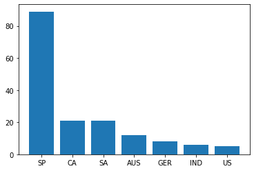

```python
plt.bar(x=df_country['Country'], height=df_country['AcceptedCmp5'])
```

# 12

```python
df.dtypes
```

```
ID                                              int64
Year_Birth                                      int64
Education                                      object
Marital_Status                                 object
Income                                        float64
Kidhome                                         int64
Teenhome                                        int64
Dt_Customer                                    object
Recency                                         int64
MntWines                                        int64
MntFruits                                       int64
MntMeatProducts                                 int64
MntFishProducts                                 int64
MntSweetProducts                                int64
MntGoldProds                                    int64
NumDealsPurchases                               int64
NumWebPurchases                                 int64
NumCatalogPurchases                             int64
NumStorePurchases                               int64
NumWebVisitsMonth                               int64
AcceptedCmp3                                    int64
AcceptedCmp4                                    int64
AcceptedCmp5                                    int64
AcceptedCmp1                                    int64
AcceptedCmp2                                    int64
Response                                        int64
Complain                                        int64
Country                                        object
age                                             int64
total_amount                                    int64
%amount_spent_on_wine_each_customer           float64
%amount_spent_on_other_prods_each_customer    float64
total_purchase                                  int64
%store_purchases_each_customer                float64
%other_channel_purchase_each_customer         float64
dtype: object
```

```python
df.drop(['%amount_spent_on_wine_each_customer', '%amount_spent_on_other_prods_each_customer', \
         '%store_purchases_each_customer', '%other_channel_purchase_each_customer'], axis=1, inplace=True)
```

```python
df.head(2)
```

|  | ID | Year_Birth | Education | Marital_Status | Income | Kidhome | Teenhome | Dt_Customer | Recency | MntWines | ... | AcceptedCmp4 | AcceptedCmp5 | AcceptedCmp1 | AcceptedCmp2 | Response | Complain | Country | age | total_amount | total_purchase |
| --- | --- | --- | --- | --- | --- | --- | --- | --- | --- | --- | --- | --- | --- | --- | --- | --- | --- | --- | --- | --- | --- |
| 0 | 1826 | 1970 | Graduation | Divorced | 84835.0 | 0 | 0 | 6/16/14 | 0 | 189 | ... | 0 | 0 | 0 | 0 | 1 | 0 | SP | 52 | 1190 | 21 |
| 1 | 1 | 1961 | Graduation | Single | 57091.0 | 0 | 0 | 6/15/14 | 0 | 464 | ... | 0 | 0 | 0 | 1 | 1 | 0 | CA | 61 | 577 | 25 |

2 rows × 31 columns

```python
df_bp = df.copy()
```

```python
df['n_depends'] = df['Kidhome'] + df['Teenhome']
df = df[df['n_depends'] > 0]
df.reset_index(drop=True, inplace=True)
df['tot_amt_v_depend'] = df['total_amount']/df['n_depends']
df['tot_amt_v_depend'] = df['tot_amt_v_depend'].round(2)
df['tot_purhcase_v_depend'] = df['total_purchase']/df['n_depends']
df['tot_purhcase_v_depend'] = df['tot_purhcase_v_depend'].round(2)
```

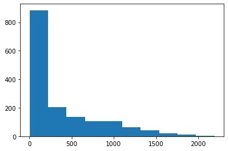

```python
plt.hist(df['tot_amt_v_depend'])
```

```python
df[['n_depends', 'total_amount']].corr()
```

|  | n_depends | total_amount |
| --- | --- | --- |
| n_depends | 1.000000 | -0.216699 |
| total_amount | -0.216699 | 1.000000 |

- No. of dependents and total amount spent are negatively correlated
- More than 800 people spend around 100 bucks per dependent

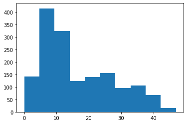

```python
plt.hist(df['tot_purhcase_v_depend'])
```

```python
df[['n_depends', 'total_purchase']].corr()
```

|  | n_depends | total_purchase |
| --- | --- | --- |
| n_depends | 1.000000 | -0.161679 |
| total_purchase | -0.161679 | 1.000000 |

- No. of dependents and total no. of purchases are negatively correlated
- Most people purchase around 8 items per dependent

# 13

```python
df.columns
```

```
Index(['ID', 'Year_Birth', 'Education', 'Marital_Status', 'Income', 'Kidhome',
       'Teenhome', 'Dt_Customer', 'Recency', 'MntWines', 'MntFruits',
       'MntMeatProducts', 'MntFishProducts', 'MntSweetProducts',
       'MntGoldProds', 'NumDealsPurchases', 'NumWebPurchases',
       'NumCatalogPurchases', 'NumStorePurchases', 'NumWebVisitsMonth',
       'AcceptedCmp3', 'AcceptedCmp4', 'AcceptedCmp5', 'AcceptedCmp1',
       'AcceptedCmp2', 'Response', 'Complain', 'Country', 'age',
       'total_amount', 'total_purchase', 'n_depends', 'tot_amt_v_depend',
       'tot_purhcase_v_depend'],
      dtype='object')
```

```python
df.drop(['n_depends', 'tot_amt_v_depend', 'tot_purhcase_v_depend'], axis=1, inplace=True)
```

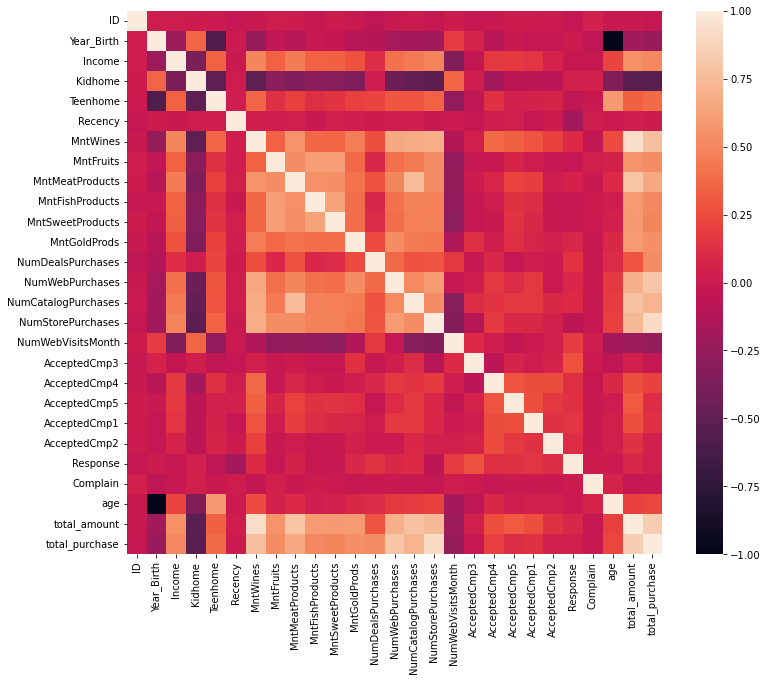

```python
plt.figure(figsize=(12,10))
sns.heatmap(df.corr())
```

# 14

```python
df = df_bp.copy()
df.columns
```

[output not shown]

```python
df_complain = df[df['Complain'] == 1]
df_complain = df_complain[['Education', 'Complain']]
```

```python
df_complain.head(1)
```

|  | Education | Complain |
| --- | --- | --- |
| 205 | 2n Cycle | 1 |

```python
df_complain = df_complain.groupby(['Education'])['Complain'].sum().reset_index().sort_values(by=['Complain'],ascending=False)
df_complain.reset_index(drop=True, inplace=True)
df_complain
```

|  | Education | Complain |
| --- | --- | --- |
| 0 | Graduation | 14 |
| 1 | 2n Cycle | 4 |
| 2 | Master | 2 |
| 3 | PhD | 1 |

```
<BarContainer object of 4 artists>
```

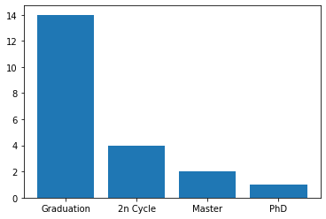

```python
# People having Graduation as a degree have complained the most

plt.bar(x=df_complain['Education'], height=df_complain['Complain'])
```

# 15

```python
df.columns
```

[output not shown]

```python
df_final = df[['total_amount', 'MntFruits', 'MntMeatProducts', 'MntFishProducts', 'MntSweetProducts',
               'MntGoldProds', 'Education', 'Marital_Status', 'Response']]
```

```python
df_final.head(2)
```

|  | total_amount | MntFruits | MntMeatProducts | MntFishProducts | MntSweetProducts | MntGoldProds | Education | Marital_Status | Response |
| --- | --- | --- | --- | --- | --- | --- | --- | --- | --- |
| 0 | 1190 | 104 | 379 | 111 | 189 | 218 | Graduation | Divorced | 1 |
| 1 | 577 | 5 | 64 | 7 | 0 | 37 | Graduation | Single | 1 |

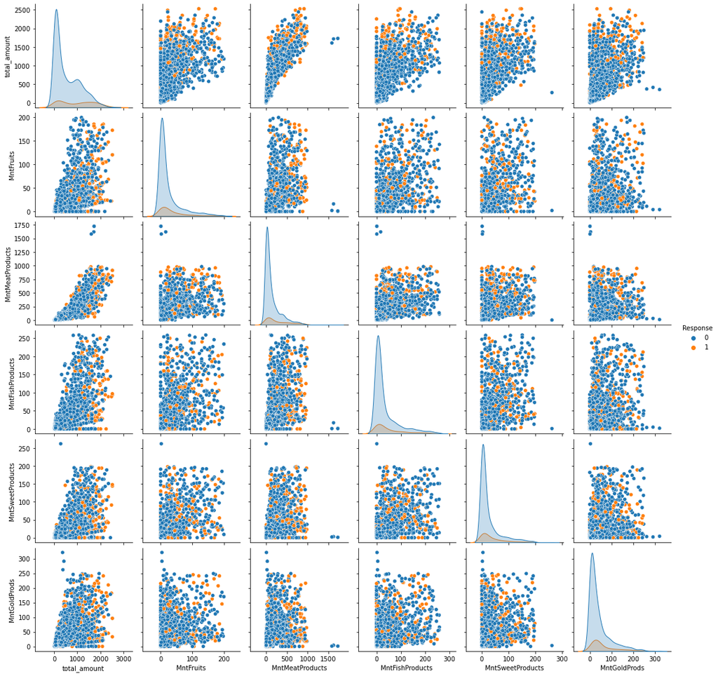

```python
sns.pairplot(df_final, hue='Response')
```

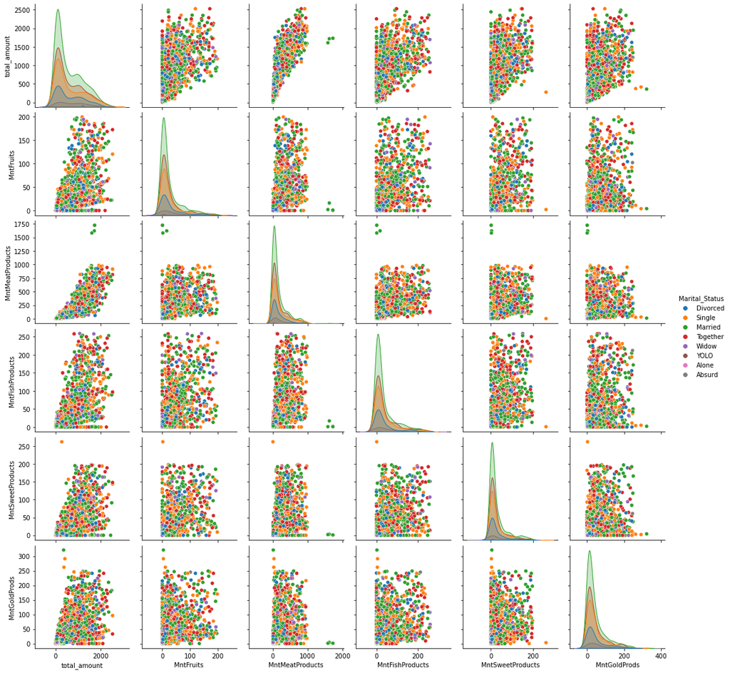

```python
sns.pairplot(df_final.drop('Response', axis=1), hue='Marital_Status')
```

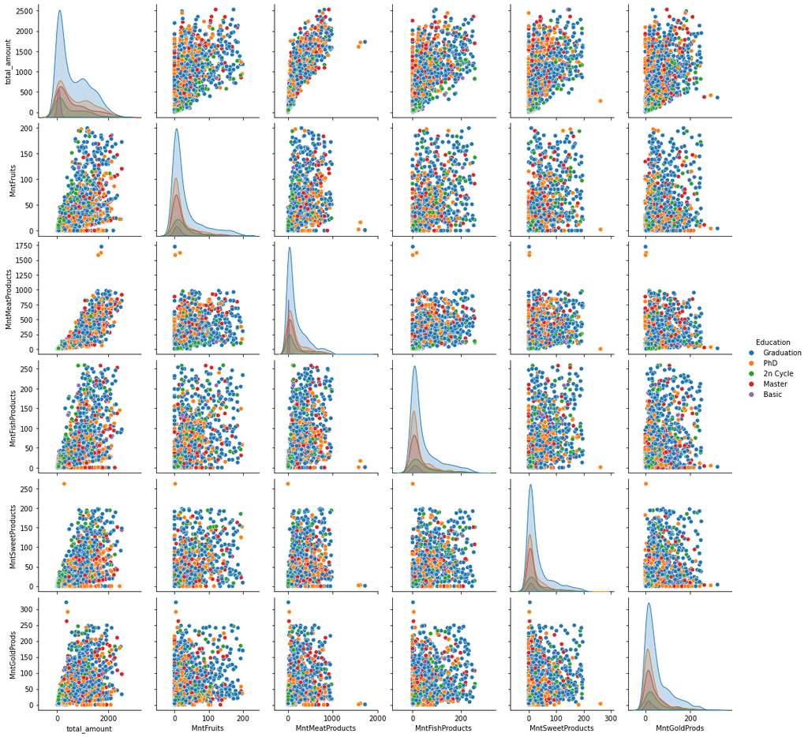

```python
sns.pairplot(df_final.drop('Response', axis=1), hue='Education')
```

- People with Response flag as 1 has higher tendency to spend more amount
- For other features like Education and Marital status there is no differentiation betweem the values
- There is no significant pattern in the amount spent for each product type